# Practical uses for provided CpG probe annotations

Sean Maden

2022-12-15

This vignette provides several practical demonstrations of how to use HM450K and EPIC platform CpG probe annotations, which are provided in the platform-specific manifests. These examples are shown for an example `RGChannelSet` using functions from the `minfi` package.

# Probe manifest background

The CpG probe manifest files were provided by Illumina and contain a number of useful fields pretaining to the genome location of a CpG probe. When we read DNAm IDAT files into a `SummarizedExperiment` object using the `minfi` package (e.g. using `read.metharray.exp()` or similar), they are automatically combined with an array platform manifest containing rich probe-level details about the probe chemistry, the genome location, and various functional features and annotations to be aware of.

## Getting the HM450K manifest annotations from an `RGChannelSet`

We can easily access the manifest of the older HM450K platform. Using an example `RGChannelSet` object from the `minfiData` package, we can extract and inspect the full HM450K platform manifest with `getAnnotation()` as follows:

```r
rg <- get(data("RGsetEx"))
man <- as.data.frame(getAnnotation(rg))
colnames(man)
```

```
##  [1] "chr"                      "pos"
##  [3] "strand"                   "Name"
##  [5] "AddressA"                 "AddressB"
##  [7] "ProbeSeqA"                "ProbeSeqB"
##  [9] "Type"                     "NextBase"
## [11] "Color"                    "Probe_rs"
## [13] "Probe_maf"                "CpG_rs"
## [15] "CpG_maf"                  "SBE_rs"
## [17] "SBE_maf"                  "Islands_Name"
## [19] "Relation_to_Island"       "Forward_Sequence"
## [21] "SourceSeq"                "Random_Loci"
## [23] "Methyl27_Loci"            "UCSC_RefGene_Name"
## [25] "UCSC_RefGene_Accession"   "UCSC_RefGene_Group"
## [27] "Phantom"                  "DMR"
## [29] "Enhancer"                 "HMM_Island"
## [31] "Regulatory_Feature_Name"  "Regulatory_Feature_Group"
## [33] "DHS"
```

Array platform manifests are made available in the Bioconductor packages `IlluminaHumanMethylation450kmanifest` and `IlluminaHumanMethylationEPICmanifest`, so be sure to have these installed before working with DNAm arrays as `SummarizedExperiment` objects. These manifests are unchanged from the original manifest files, which can be accessed from Illumina’s website. The HM450K manifest can be found [here](https://support.illumina.com/array/array_kits/infinium_humanmethylation450_beadchip_kit/downloads.html), and the EPIC manifest can be found [here](https://support.illumina.com/array/array_kits/infinium-methylationepic-beadchip-kit/downloads.html). The official documents also include detailed descriptions of the manifest columns.

## Getting the EPIC manifest annotations from an `RGChannelSet`

The newer EPIC platform contains a manifest with updated probe information, including several new annotation columns useful for probe filters.

```r
rg.epic <- get(data("RGsetEPIC"))
man.epic <- as.data.frame(getAnnotation(rg.epic))
colnames(man.epic)
```

```
##  [1] "chr"
##  [2] "pos"
##  [3] "strand"
##  [4] "Name"
##  [5] "AddressA"
##  [6] "AddressB"
##  [7] "ProbeSeqA"
##  [8] "ProbeSeqB"
##  [9] "Type"
## [10] "NextBase"
## [11] "Color"
## [12] "Probe_rs"
## [13] "Probe_maf"
## [14] "CpG_rs"
## [15] "CpG_maf"
```

[output cut: 31 more lines]

# Annotation-based probe filters

## Filtering on common SNPs

We can filter a probe based on high likelihood of a confounding single nucleotide polymorphism (SNP), or a variant that occurs near a probe (e.g. within the 50bp annealing sequence), or if it overlaps the exact CpG location. These probe-proximal SNPs can be identified either from the manifest (see above), or accessed independently using `getSnpInfo()`. For instance:

```r
getSnpInfo(rg)
```

```
## DataFrame with 485512 rows and 6 columns
##                    Probe_rs Probe_maf      CpG_rs   CpG_maf      SBE_rs
##                 <character> <numeric> <character> <numeric> <character>
## cg00050873               NA        NA          NA        NA          NA
## cg00212031               NA        NA          NA        NA          NA
## cg00213748               NA        NA          NA        NA          NA
## cg00214611               NA        NA          NA        NA          NA
## cg00455876               NA        NA          NA        NA          NA
## ...                     ...       ...         ...       ...         ...
## ch.22.909671F            NA        NA          NA        NA          NA
## ch.22.46830341F          NA        NA          NA        NA          NA
## ch.22.1008279F           NA        NA          NA        NA          NA
## ch.22.47579720R  rs79009754  0.012587          NA        NA          NA
## ch.22.48274842R  rs79812973  0.022589          NA        NA          NA
##                   SBE_maf
##                 <numeric>
## cg00050873             NA
## cg00212031             NA
## cg00213748             NA
## cg00214611             NA
## cg00455876             NA
## ...                   ...
## ch.22.909671F          NA
## ch.22.46830341F        NA
## ch.22.1008279F         NA
## ch.22.47579720R        NA
## ch.22.48274842R        NA
```

It is recommended that CpG probes which contain a common SNP be filtered prior to analysis. Common SNPs are identified based on their minor allele frequency (MAF, e.g. from columns `Probe_maf`, `CpG_maf`, or `SBE_maf`).

The function `dropLociWithSnps()` allows one to filter a mapped `MethylSet` or `RatioSet` based on the SNP MAF frequency. For example:

```r
gm <- preprocessRaw(rg) # make MethylSet
gms <- mapToGenome(gm) # make GenomicMethylSet
gmsf <- dropLociWithSnps(gms) # filter probes with SNPs
```

The minimum MAF frequency filter can be changed in `dropLociWithSnps()` by setting the `maf` argument. See `?dropLociWithSnps` for details. Also note the SNP information is a product of its reference, and details about the specific genetic variant databases mined for this SNP info can be found in the manifest documentation (see above).

## Filtering on cross-reactive CpG probes

A number of probes on both the EPIC and HM450K platforms were previously found to possess high cross-reactivity, an undesirable quality that limits probe measurement reliability. We can identify and remove probes with evidence of cross-reactivity from either platform by simply filtering on the identifiers of the probes to be removed. Several commonly utilized sources of CpG IDs for cross-reactive probes include:

- Chen et al 2013 cross-reactive HM450K probes ([source](https://www.tandfonline.com/doi/full/10.4161/epi.23470)). Note, these probes have been uploaded [here](https://github.com/metamaden/methyPre/tree/master/data).
- Pidsley et al 2016 cross-reactive EPIC probes ([source](https://genomebiology.biomedcentral.com/articles/10.1186/s13059-016-1066-1)). Note, these probes have also been uploaded [here](https://github.com/metamaden/methyPre/tree/master/data).

We can filter out lists of probe CpG IDs (e.g. `cg00050873`) by subsetting on the `Name` column in the manifest.

# Querying and quantifying genome regions and functional groups

Many DNAm studies note whether methylation occurs in a gene’s promoter or body region. One reason is that we expect the functional consequences of DNAm to vary given its location in a gene, or indeed if it occurs in a gene at all. Another common way to annotate CpG probes is according to their position relative to protein-coding gene regions as well as relative to cytosine- and guanine-dense regions called CpG Islands. We can quickly group probes according to either their gene or CpG Island region using information in the manifest, as shown below.

## Find probes mapping to a gene

The gene IDs can be found under the columns `UCSC_RefGene_Name` (for the common gene name) and `UCSC_RefGene_Accession` (for the official RefGene accession). Note that entries in these columns correspond to transcript labels, so gene names and IDs may be repeated multiple times separated by a semi-colon character. This formatting means we need to use regular expression to isolate all the probes by a given gene name.

We can quantify the number of intergenic (non-gene-mapping) and genic (gene-mapping) probes with:

```r
as.data.frame(table(man$UCSC_RefGene_Name==""))
```

```
##    Var1   Freq
## 1 FALSE 365860
## 2  TRUE 119652
```

We can further grab all probes mapping to the gene `ARID1A` using:

```r
gene.str <- "ARID1A" # common gene name
gene.patt <- paste0("(^|;)", gene.str, "($|;)") # regex pattern
which.gene <- which(grepl(gene.patt, man$UCSC_RefGene_Name)) # gene filter
manf <- man[which.gene,]
dim(manf)
```

```
## [1] 29 33
```

## Viewing gene functional region frequencies

We can find the gene relation annotations under the column `UCSC_RefGene_Group` in the manifest. Values under this column are either blank, if a probe does not map to a gene (a.k.a. “intergenic probes”), or contains one or more location annotations corresponding to various overlapping transcript IDs.

To get all mapped gene regions as a vector, use:

```r
gene.regionv <- unlist(strsplit(man$UCSC_RefGene_Group, ";"))
```

To view all possible group values, we can use:

```r
unique(gene.regionv)
```

```
## [1] "Body"    "TSS1500" "TSS200"  "1stExon" "5'UTR"   "3'UTR"
```

To view the frequency with which each region is mapped by an array probe, use:

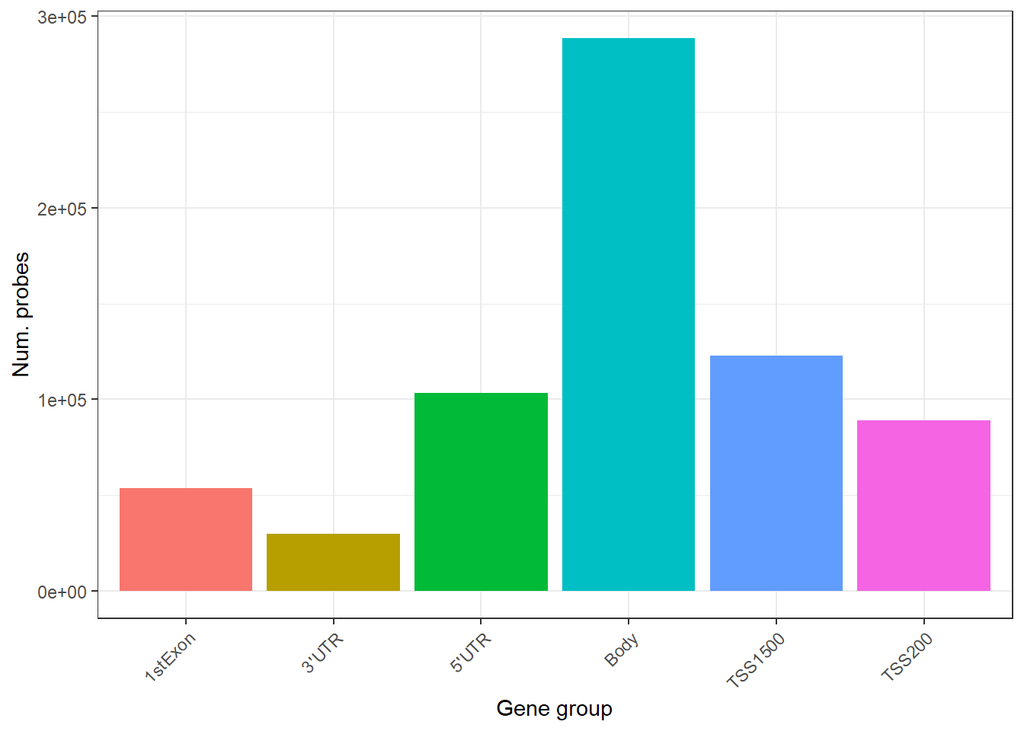

```r
df <- as.data.frame(table(gene.regionv)) # get group frequencies
ggplot(df, aes(x = gene.regionv, y = Freq, fill = gene.regionv)) + theme_bw() +
  geom_bar( stat = "identity") + xlab("Gene group") + ylab("Num. probes") +
  theme(legend.position = "none",
        axis.text.x = element_text(angle = 45, hjust = 1))
```

## Identifying promoter-mapping and gene body-mapping CpG probes

We can use this logic of the `UCSC_RefGene_Group` variable to build conditions for new functional regions of interest, namely promoter and gene body regions.

```r
# make pattern: "(^|;)5'UTR($|;)|(^|;)TSS1500($|;)|(^|;)TSS500($|;)"
prom.catv <- c("5'UTR", "TSS1500", "TSS500")
prom.patt <- paste0("(^|;)", prom.catv, "($|;)", collapse = "|")
# use regex to detect promoter-mapping probes
man$promoter <- ifelse(grepl(prom.patt, man$UCSC_RefGene_Group),
                       TRUE, FALSE)
as.data.frame(table(man$promoter))
```

```
##    Var1   Freq
## 1 FALSE 345715
## 2  TRUE 139797
```

One way we can define the gene body is as all gene-mapping probes which don’t map to the gene promoter. Using a similar strategy as for the new `promoter` variable, we can define a new `gene_body` variable with:

```r
# make pattern: "(^|;)Body($|;)|(^|;)3'UTR($|;)"
body.catv <- c("Body", "3'UTR")
body.patt <- paste0("(^|;)", body.catv, "($|;)", collapse = "|")
# use regex to detect body-mapping probes
man$gene_body <- ifelse(grepl(body.patt, man$UCSC_RefGene_Group),
                       TRUE, FALSE)
table(man$gene_body)
```

```
##
##  FALSE   TRUE
## 292622 192890
```

Since the manifest is transcript-centric, you will find that some probes map to the promoter of one transcript and the body of another transcript. You can view these as follows:

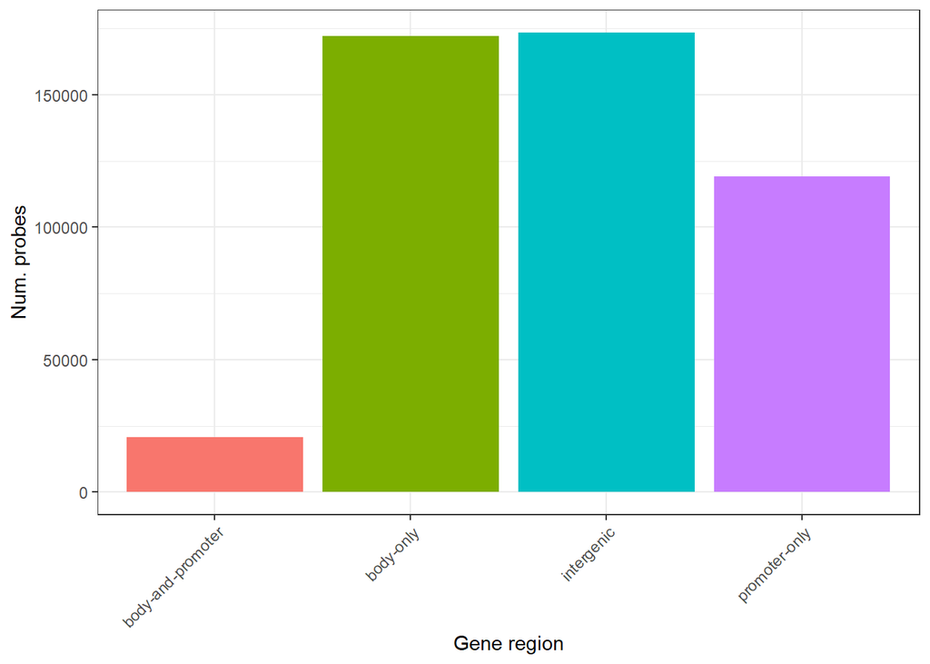

```r
dfp <- as.data.frame(table(man$gene_body, man$promoter))
dfp$region <- c("intergenic", "body-only", "promoter-only", "body-and-promoter")
ggplot(dfp, aes(x = region, y = Freq, fill = region)) + theme_bw() +
  geom_bar( stat = "identity") + xlab("Gene region") + ylab("Num. probes") +
  theme(legend.position = "none",
        axis.text.x = element_text(angle = 45, hjust = 1))
```

## CpG Island annotations

It is comparatively straightforward to view a probe’s relation to a CpG Island from the manifest using the variable `Relation_to_Island`.

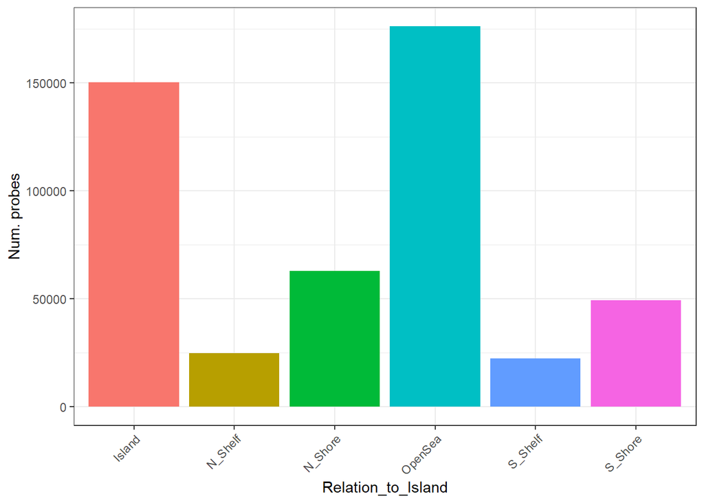

```r
dfp <- as.data.frame(table(man$Relation_to_Island))
ggplot(dfp, aes(x = Var1, y = Freq, fill = Var1)) + theme_bw() +
  geom_bar(stat = "identity") + xlab("Relation_to_Island") + ylab("Num. probes") +
  theme(legend.position = "none",
        axis.text.x = element_text(angle = 45, hjust = 1))
```

It is also easy to add the “genic” information, or whether a probe maps to a gene, alongside the CpG Island annotations, as follows:

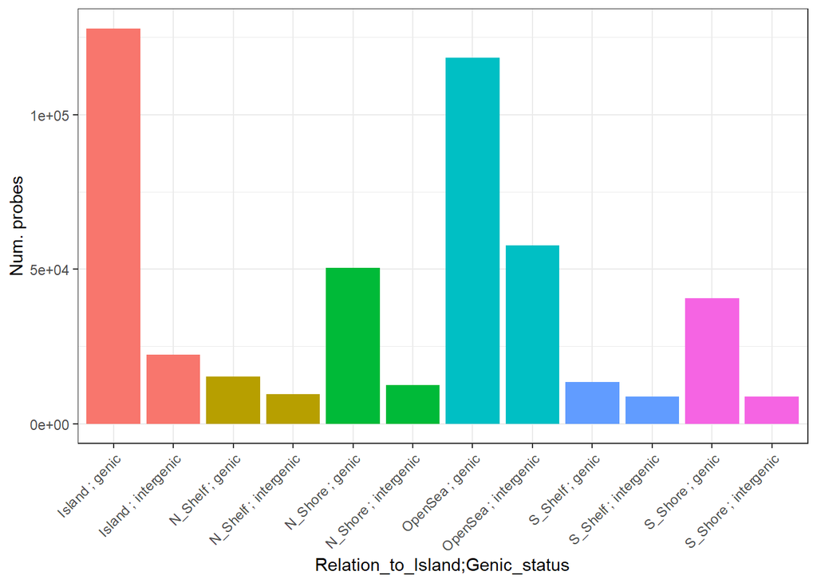

```r
dfp <- as.data.frame(table(man$Relation_to_Island, man$UCSC_RefGene_Name==""))
dfp$region <- paste0(dfp$Var1," ; ", c(rep("genic", 6), rep("intergenic", 6)))
ggplot(dfp, aes(x = region, y = Freq, fill = Var1)) + theme_bw() +
  geom_bar(stat = "identity") + xlab("Relation_to_Island;Genic_status") +
  ylab("Num. probes") +
  theme(legend.position = "none",
        axis.text.x = element_text(angle = 45, hjust = 1))
```

# Conclusions

This vignette described practical uses for the platform-specific, manifest-based annotations for CpG probes on HM450K and EPIC platforms. Additional resources, information, and guidance for analyzing compilations of DNAm array datasets can be found in the following vignettes:

- [`recountmethylation`] R/Bioconductor package documentation
- `minfi` R/Bioconductor package and documentation